# BathSoap

Nhóm 20

6/27/2021

Thành viên :

```
Trương Hùng Anh- 18133001

Nguyễn Xuân Hiệu – 18133013

Nguyễn Tuấn Vũ – 18133064

Trần Thị Lệ Xuân – 18133066

          GVHD: Quách Đình Hoàng
```

1. Giới thiệu chung

Giới thiệu về bài toán giải quyết

CRISA có các thị trường phân khúc truyền thống trên cơ sở nhân khẩu học của người mua. Bây giờ họ muốn phân khúc thị trường dựa trên hai bộ biến chính liên quan trực tiếp hơn đến quá trình mua hàng và lòng trung thành với thương hiệu:

1.1 Hành vi mua hàng (khối lượng, tần suất, dễ bị giảm giá và lòng trung thành với thương hiệu)

1.2 Cơ sở mua (giá, đề xuất bán)

Làm như vậy sẽ cho phép CRISA có được thông tin về những thuộc tính nhân khẩu học nào có liên quan đến các hành vi mua hàng khác nhau và mức độ trung thành với thương hiệu và triển khai ngân sách khuyến mãi hiệu quả hơn.

Phân khúc thị trường tốt hơn và hiệu quả hơn sẽ cho phép khách hàng của CRISA thiết kế các chương trình khuyến mãi hiệu quả hơn về chi phí nhắm vào các phân khúc phù hợp. Do đó, nhiều chương trình khuyến mãi có thể được tung ra, mỗi chương trình nhắm mục tiêu vào các phân khúc thị trường khác nhau vào các thời điểm khác nhau trong một năm. Điều này sẽ dẫn đến việc phân bổ ngân sách khuyến mãi hiệu quả hơn cho các thị trường khác nhau. Nó cũng sẽ cho phép CRISA thiết kế các hệ thống phần thưởng khách hàng hiệu quả hơn và do đó tăng lòng trung thành với thương hiệu.

Input: Các biến được sử dụng cho vấn đề:Avg..Price, Trans…Brand.Runs, No..of..Trans,No..of.Brands, Others.999, Total.Volume, Value,maxBrCd

Output: Sử dụng thuật toán K-means để xác định các nhóm hộ gia đình dữa trên các biến nhập vào?

2. Giới thiệu tập dữ liệu

| MEM | SEC | FEH | MT | SEX | AGE | EDU | HS | CHILD | CS | Affluence.Index | No..of.Brands | Brand.Runs | Total.Volume | No..of..Trans | Value | Trans...Brand.Runs | Vol.Tran | Avg..Price | Pur.Vol.No.Promo | Pur.Vol.Promo.6 | Pur.Vol.Other.Promo | Br..Cd..57..144 | Br..Cd..55 | Br..Cd..272 | Br..Cd..286 | Br..Cd..24 | Br..Cd..481 | Br..Cd..352 | Br..Cd..5 | … |
| --- | --- | --- | --- | --- | --- | --- | --- | --- | --- | --- | --- | --- | --- | --- | --- | --- | --- | --- | --- | --- | --- | --- | --- | --- | --- | --- | --- | --- | --- | --- |
| 1010010 | 4 | 3 | 10 | 1 | 4 | 4 | 2 | 4 | 1 | 2 | 3 | 17 | 8025 | 24 | 818.00 | 1.41 | 334.38 | 10.19 | 1.00 | 0.00 | 0.00 | 0.38 | 0.13 | 0.00 | 0.00 | 0.00 | 0.00 | 0.00 | 0.00 | … |
| 1010020 | 3 | 2 | 10 | 2 | 2 | 4 | 4 | 2 | 1 | 19 | 5 | 25 | 13975 | 40 | 1681.50 | 1.60 | 349.38 | 12.03 | 0.89 | 0.10 | 0.02 | 0.02 | 0.08 | 0.00 | 0.00 | 0.00 | 0.06 | 0.00 | 0.15 | … |
| 1014020 | 2 | 3 | 10 | 2 | 4 | 5 | 6 | 4 | 1 | 23 | 5 | 37 | 23100 | 63 | 1950.00 | 1.70 | 366.67 | 8.44 | 0.94 | 0.02 | 0.04 | 0.03 | 0.55 | 0.00 | 0.03 | 0.00 | 0.00 | 0.00 | 0.02 | … |
| 1014030 | 4 | 0 | 0 | 0 | 4 | 0 | 0 | 5 | 0 | 0 | 2 | 4 | 1500 | 4 | 114.00 | 1.00 | 375.00 | 7.60 | 1.00 | 0.00 | 0.00 | 0.40 | 0.60 | 0.00 | 0.00 | 0.00 | 0.00 | 0.00 | 0.00 | … |
| 1014190 | 4 | 1 | 10 | 2 | 3 | 4 | 4 | 3 | 1 | 10 | 3 | 6 | 8300 | 13 | 591.00 | 2.17 | 638.46 | 7.12 | 0.61 | 0.15 | 0.24 | 0.05 | 0.15 | 0.00 | 0.00 | 0.00 | 0.00 | 0.00 | 0.00 | … |
| 1017020 | 4 | 3 | 10 | 2 | 3 | 4 | 5 | 2 | 1 | 13 | 3 | 26 | 18175 | 41 | 1705.50 | 1.58 | 443.29 | 9.38 | 1.00 | 0.00 | 0.00 | 0.08 | 0.07 | 0.00 | 0.00 | 0.00 | 0.00 | 0.00 | 0.00 | … |
| 1017110 | 4 | 2 | 10 | 2 | 4 | 1 | 3 | 2 | 1 | 11 | 4 | 17 | 9950 | 26 | 1007.50 | 1.53 | 382.69 | 10.13 | 0.98 | 0.02 | 0.00 | 0.45 | 0.05 | 0.01 | 0.00 | 0.00 | 0.00 | 0.00 | 0.00 | … |
| 1017160 | 4 | 3 | 10 | 2 | 2 | 4 | 5 | 3 | 0 | 0 | 3 | 8 | 9300 | 25 | 569.50 | 3.13 | 372.00 | 6.12 | 0.94 | 0.00 | 0.07 | 0.04 | 0.79 | 0.00 | 0.00 | 0.00 | 0.00 | 0.00 | 0.00 | … |
| 1017360 | 4 | 3 | 10 | 2 | 4 | 4 | 6 | 4 | 1 | 17 | 2 | 12 | 26490 | 27 | 3113.50 | 2.25 | 981.11 | 11.75 | 0.90 | 0.10 | 0.00 | 0.39 | 0.00 | 0.00 | 0.00 | 0.00 | 0.00 | 0.00 | 0.00 | … |
| 1017460 | 1 | 3 | 5 | 1 | 4 | 7 | 3 | 4 | 1 | 6 | 4 | 13 | 7455 | 18 | 990.50 | 1.38 | 414.17 | 13.29 | 1.00 | 0.00 | 0.00 | 0.07 | 0.12 | 0.00 | 0.00 | 0.00 | 0.00 | 0.00 | 0.40 | … |

[output cut: 590 more lines]

1. MEM: Mã định danh duy nhất cho mỗi hộ gia đình
2. SEC: Loại kinh tế xã hội (1 = cao, 5 = thấp)
3. FEH: Thói quen ăn uống thực phẩm (1 = ăn chay, 2 = rau nhưng ăn trứng, 3 = không ăn chay., 0 = không được chỉ định)
4. MT: Ngôn ngữ mẹ đẻ (xem bảng trong trang tính)
5. SEX: Giới tính (Nam, nữ)
6. AGE: Tuổi
7. EDU:Giáo dục
8. HS: Số lượng thành viên trong gia đình
9. CHILD:Số trẻ em trong gia đình
10. CS: Tivi (có/ Không)
11. Affluence Index: Chỉ số giàu có
12. No. of Brands: Số lượng thương hiệu đã mua
13. Brand Runs: Số lượng trường hợp mua liên tiếp của các thương hiệu
14. Total Volume:
15. No. of Trans: Số lượng giao dịch mua hàng; Nhiều thương hiệu được mua trong một tháng được tính là các giao dịch riêng biệt
16. Value: Tổng giá trị
17. Trans / Brand Runs: Giao dịch trung bình trên mỗi thương hiệu.
18. Vol/Tran :
19. Avg. Price: Giá trị mua trung bình
20. Pur Vol No Promo - %: Phần trăm khối lượng mua theo chương trình khuyến mãi/không khuyến mãi
21. Pur Vol Promo 6 %: Phần trăm khối lượng mua theo Mã khuyến mãi 6
22. Pur Vol Other Promo % : Phần trăm khối lượng mua theo các chương trình khuyến mãi khác
23. Br. Cd. (57, 144), 55, 272, 286, 24, 481, 352,5 and 999 (others): : Phần trăm khối lượng mua của thương hiệu
24. Price Cat 1 to 4 :Phần trăm khối lượng mua theo danh mục giá
25. Proposition Cat 5 to 15 : Phần trăm khối lượng mua theo danh mục đề xuất sản phẩm

```
## dbscan Pts=600 MinPts=5 eps=0.01
##
##   0
## 600
```

```
## dbscan Pts=600 MinPts=5 eps=0.1
##
##   0
## 600
```

| Avg..Price | Trans...Brand.Runs | No..of..Trans | No..of.Brands | Others.999 | Total.Volume | Value | maxBrCd |
| --- | --- | --- | --- | --- | --- | --- | --- |
| 10.19 | 1.41 | 24 | 3 | 0.49 | 8025 | 818.00 | 0.377 |
| 12.03 | 1.60 | 40 | 5 | 0.70 | 13975 | 1681.50 | 0.145 |
| 8.44 | 1.70 | 63 | 5 | 0.38 | 23100 | 1950.00 | 0.545 |
| 7.60 | 1.00 | 4 | 2 | 0.00 | 1500 | 114.00 | 0.600 |
| 7.12 | 2.17 | 13 | 3 | 0.81 | 8300 | 591.00 | 0.145 |
| 9.38 | 1.58 | 41 | 3 | 0.86 | 18175 | 1705.50 | 0.077 |
| 10.13 | 1.53 | 26 | 4 | 0.50 | 9950 | 1007.50 | 0.452 |
| 6.12 | 3.13 | 25 | 3 | 0.17 | 9300 | 569.50 | 0.790 |
| 11.75 | 2.25 | 27 | 2 | 0.62 | 26490 | 3113.50 | 0.385 |
| 13.29 | 1.38 | 18 | 4 | 0.41 | 7455 | 990.50 | 0.402 |

[output cut: 590 more lines]

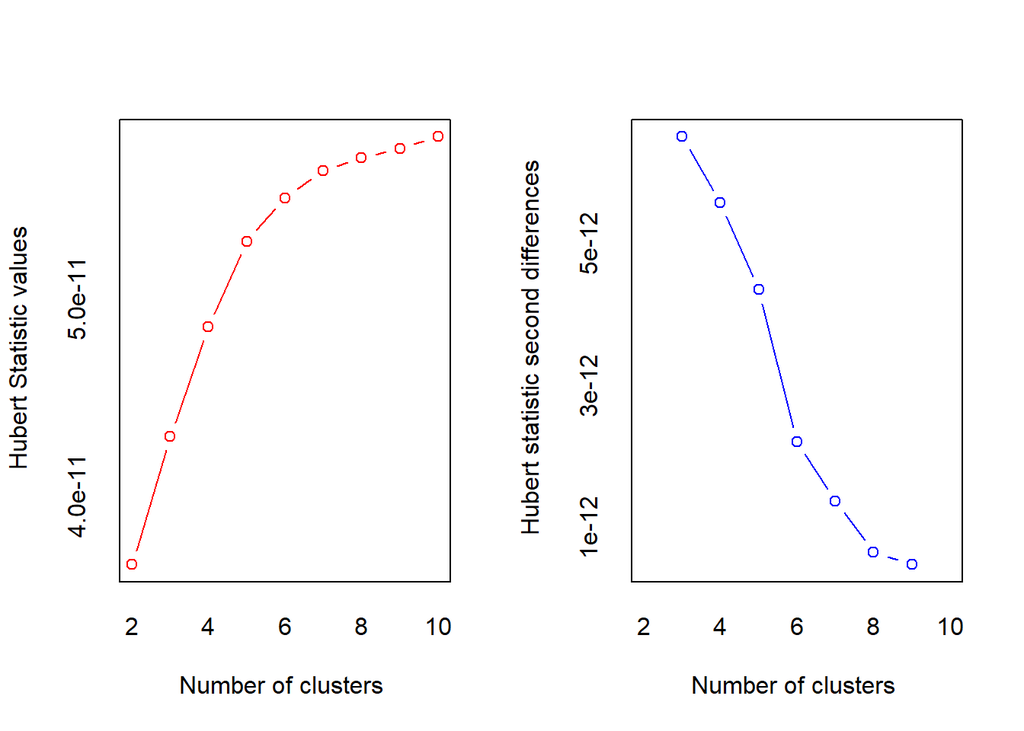

```
## *** : The Hubert index is a graphical method of determining the number of clusters.
##                 In the plot of Hubert index, we seek a significant knee that corresponds to a
##                 significant increase of the value of the measure i.e the significant peak in Hubert
##                 index second differences plot.
##
```

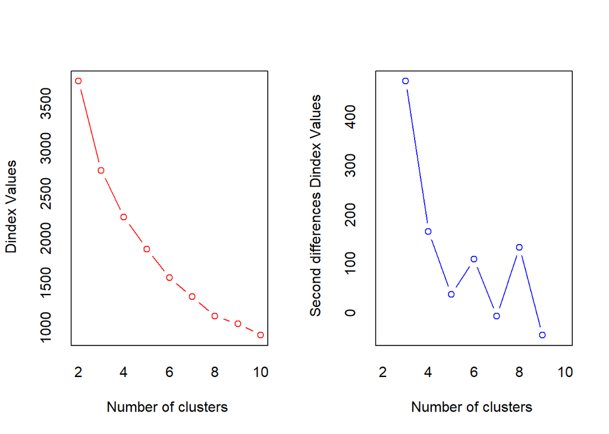

```
## *** : The D index is a graphical method of determining the number of clusters.
##                 In the plot of D index, we seek a significant knee (the significant peak in Dindex
##                 second differences plot) that corresponds to a significant increase of the value of
##                 the measure.
##
## * Among all indices:
## * 5 proposed 2 as the best number of clusters
## * 9 proposed 3 as the best number of clusters
## * 1 proposed 4 as the best number of clusters
## * 1 proposed 7 as the best number of clusters
## * 3 proposed 8 as the best number of clusters
## * 5 proposed 10 as the best number of clusters
##
##                    ***** Conclusion *****
##
## * According to the majority rule, the best number of clusters is  3
##
##
```

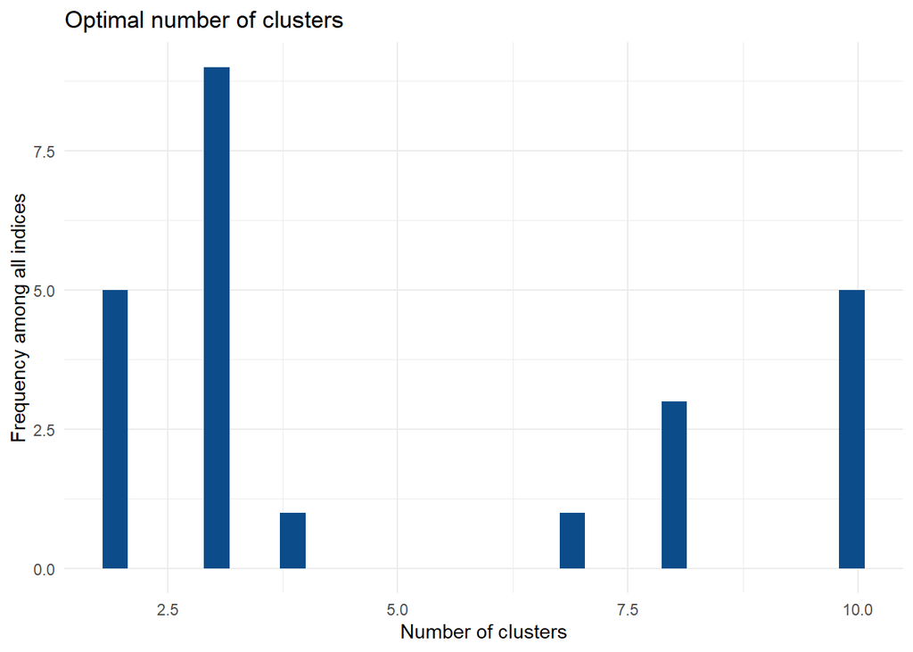

```
## K-means clustering with 3 clusters of sizes 302, 64, 234
##
## Cluster means:
##   Avg..Price Trans...Brand.Runs No..of..Trans No..of.Brands Others.999
## 1   12.85990           2.161391      23.20861      3.370861  0.5332119
## 2   10.13781           4.089062      42.62500      3.812500  0.4748438
## 3   10.97573           2.804402      38.26923      3.931624  0.5215812
##   Total.Volume     Value   maxBrCd
## 1     6332.682  808.6536 0.3621457
## 2    28448.203 2920.0367 0.4373750
## 3    14597.038 1586.9065 0.3648632
##
## Clustering vector:
##   [1] 1 3 2 1 1 3 1 1 2 1 3 3 3 3 1 3 3 3 3 1 1 1 2 1 1 3 3 3 3 1 3 1 1 2 3 3 1
##  [38] 1 3 1 1 3 2 1 2 1 1 1 1 3 3 3 1 2 3 3 2 3 2 1 3 3 3 3 3 1 2 2 1 3 1 3 3 1
##  [75] 3 1 1 1 3 1 1 2 3 1 1 3 3 2 1 3 3 2 1 1 3 3 3 3 1 3 3 3 2 3 3 3 3 3 3 1 3
## [112] 3 3 3 3 1 3 1 3 1 3 3 3 2 2 2 2 3 1 3 3 3 1 1 1 1 3 1 3 2 3 3 3 3 3 3 1 1
## [149] 1 1 1 1 1 3 3 3 1 1 1 2 3 2 2 3 2 3 2 1 3 3 3 1 1 1 2 3 2 3 2 3 1 3 3 1 3
## [186] 3 2 3 2 3 3 3 1 3 3 1 3 1 3 3 3 2 2 1 1 1 1 2 3 3 3 1 3 3 2 1 3 1 3 3 3 2
## [223] 3 1 1 1 3 3 1 1 3 2 3 2 1 3 3 3 2 1 3 1 1 1 3 1 1 1 1 1 1 1 1 3 3 1 3 3 2
## [260] 1 1 1 1 3 3 3 3 3 3 1 2 2 1 1 3 3 3 3 1 1 2 3 3 2 3 1 1 3 3 3 3 1 1 3 1 3
## [297] 3 3 3 3 1 1 1 3 1 3 1 1 1 1 3 3 2 1 2 3 3 3 3 3 2 1 2 2 1 1 2 3 3 3 3 1 1
## [334] 1 1 1 3 1 1 3 1 1 3 1 1 1 3 3 3 1 1 1 3 3 3 3 2 3 3 3 1 1 3 2 3 1 1 1 1 1
## [371] 1 1 3 1 3 1 1 1 3 1 1 1 3 1 3 1 1 3 1 1 2 1 1 1 3 1 1 1 1 1 1 3 3 1 1 1 1
## [408] 1 3 1 3 1 1 3 1 1 1 1 3 1 2 1 1 3 1 3 1 1 1 1 2 3 3 1 1 3 3 3 1 1 1 1 1 1
## [445] 1 1 1 1 1 1 1 1 3 1 1 3 3 2 3 1 1 1 1 3 3 2 1 1 1 1 1 1 1 1 3 2 3 1 1 2 1
## [482] 1 1 3 1 1 1 1 1 1 1 3 1 3 2 1 1 1 2 3 3 1 1 3 1 1 1 1 3 1 1 1 3 3 1 1 1 1
## [519] 1 3 1 1 1 2 1 3 1 1 3 1 1 1 3 1 1 1 1 1 1 1 1 1 3 3 3 3 1 1 3 3 1 1 1 3 3
## [556] 1 3 1 1 1 1 3 1 3 3 1 1 1 1 3 1 3 1 1 2 1 3 1 1 1 1 1 3 1 1 1 2 1 1 3 1 1
## [593] 1 1 1 1 1 2 1 3
##
## Within cluster sum of squares by cluster:
## [1] 2496549863 3181579393 2108335103
##  (between_SS / total_SS =  78.7 %)
##
## Available components:
##
## [1] "cluster"      "centers"      "totss"        "withinss"     "tot.withinss"
## [6] "betweenss"    "size"         "iter"         "ifault"
```

## Biểu đồ phân cụm của k-means

```
## .
##   1   2   3
## 302  64 234
```

[figure not shown]

## Chọn k tối ưu - thuật toán K-Medoids

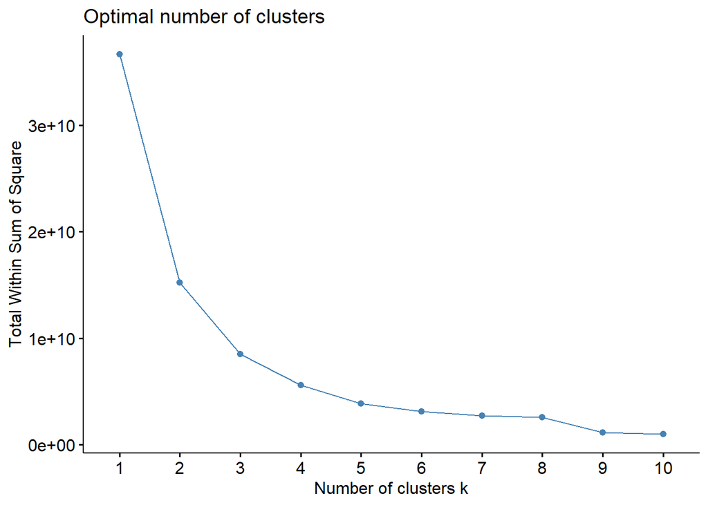

## Kết quả phân tích k-Mediods với k =3

```
## Medoids:
##       ID Avg..Price Trans...Brand.Runs No..of..Trans No..of.Brands Others.999
## [1,] 591      12.64               2.13            32             2       0.53
## [2,] 155      11.43               3.05            58             3       0.60
## [3,] 208      10.48               1.80            27             3       0.82
##      Total.Volume   Value maxBrCd
## [1,]         6100  771.00   0.475
## [2,]        12085 1381.55   0.281
## [3,]        22500 2357.50   0.144
## Clustering vector:
##   [1] 1 2 3 1 1 3 2 2 3 1 2 2 3 2 2 2 3 2 2 1 1 1 3 1 1 2 2 2 2 1 2 1 1 3 3 2 1
##  [38] 2 2 1 2 2 3 1 3 2 1 2 1 3 3 2 1 3 2 3 3 3 3 1 3 3 3 2 2 2 3 3 2 2 2 2 2 1
##  [75] 2 1 1 1 3 1 1 3 2 1 1 3 2 3 1 2 2 3 1 2 2 2 3 2 1 2 2 2 3 2 2 2 3 2 2 2 2
## [112] 2 2 3 3 2 2 1 2 1 2 2 2 3 3 3 3 2 1 3 3 3 1 1 1 1 2 1 2 3 2 2 2 2 2 2 1 2
## [149] 2 2 1 1 1 2 2 2 2 1 1 3 3 3 3 3 3 2 3 1 3 2 2 1 1 2 3 2 3 2 3 2 1 3 2 1 3
```

[output cut: 19 more lines]

## Biểu đồ với k =3

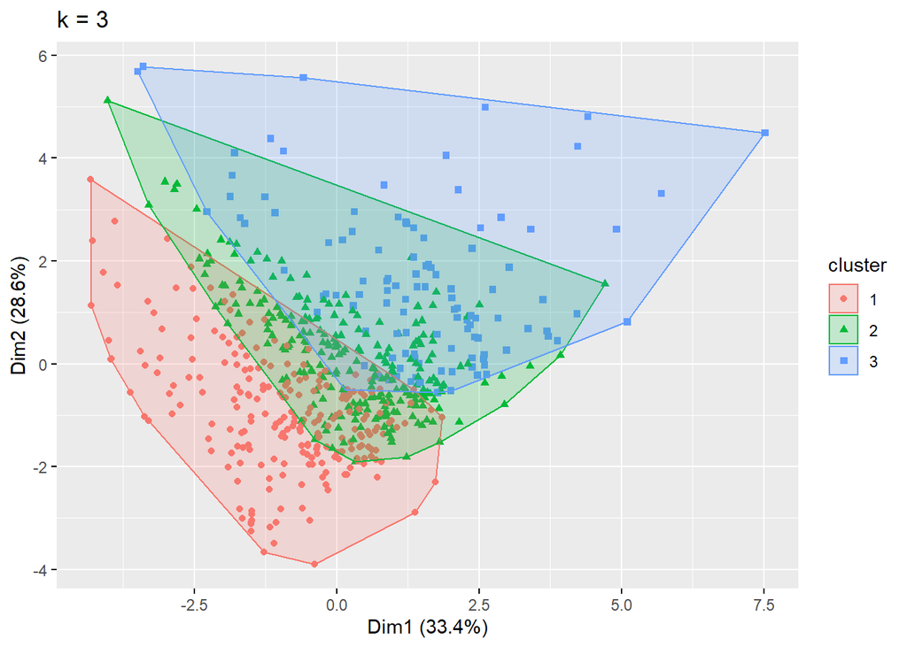

## So sánh 2 thuật toán

```
##   cluster size ave.sil.width
## 1       1  302          0.57
## 2       2   64          0.45
## 3       3  234          0.51
```

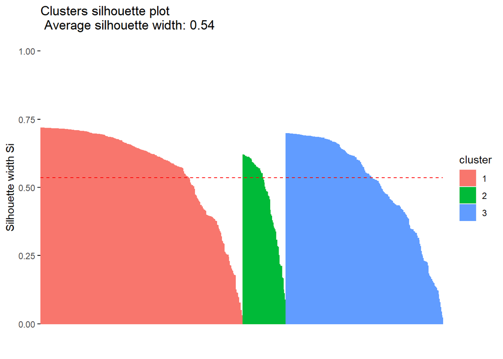

```
##   cluster size ave.sil.width
## 1       1  238          0.55
## 2       2  250          0.55
## 3       3  112          0.34
```

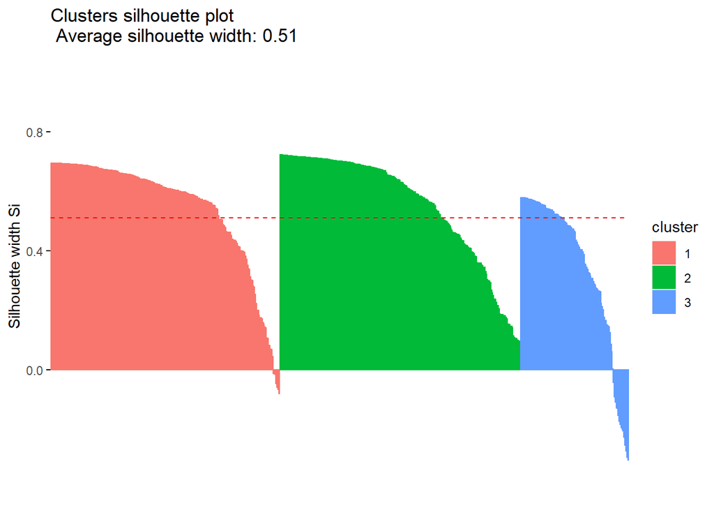

- Dựa vào thông số trên ta thấy phân cụm của Kmeans có thông số Silhouette Coeﬃcient gần 1 hơn so với phân cum bằng K-Medoids nên thuật toán K-Means là thuật toán tốt hơn cho tập dữ liệu này
- Silhouette coeﬀicient là trung bình của các Si. Giá trị càng gần +1 mô tả clustering càng tốt

Bài toán số 2: Phân tích dựa trên Các biến mô tả cơ sở mua hàng

Các biến được sử dụng cho quá trình này là:

```
  Tất cả các loại giá

  Bán đề xuất
```

Chi tiết:

[output not shown]

Biến Input: Pur.Vol.No.Promo, Pur.Vol.Promo.6, Pur.Vol.Other.Promo, Pr.Cat.1, Pr.Cat.2, Pr.Cat.3, Pr.Cat.4, PropCat.5, PropCat.6, PropCat.8, PropCat.12, PropCat.15, maxBrCd

Biến Output: Sử dụng thuật toán K-means để xác định các nhóm hộ gia đình dữa trên các biến nhập vào

| MEM | SEC | FEH | MT | SEX | AGE | EDU | HS | CHILD | CS | Affluence.Index | No..of.Brands | Brand.Runs | Total.Volume | No..of..Trans | Value | Trans...Brand.Runs | Vol.Tran | Avg..Price | Pur.Vol.No.Promo | Pur.Vol.Promo.6 | Pur.Vol.Other.Promo | Br..Cd..57..144 | Br..Cd..55 | Br..Cd..272 | Br..Cd..286 | Br..Cd..24 | Br..Cd..481 | Br..Cd..352 | Br..Cd..5 | … |
| --- | --- | --- | --- | --- | --- | --- | --- | --- | --- | --- | --- | --- | --- | --- | --- | --- | --- | --- | --- | --- | --- | --- | --- | --- | --- | --- | --- | --- | --- | --- |
| 1010010 | 4 | 3 | 10 | 1 | 4 | 4 | 2 | 4 | 1 | 2 | 3 | 17 | 8025 | 24 | 818.00 | 1.41 | 334.38 | 10.19 | 1.00 | 0.00 | 0.00 | 0.38 | 0.13 | 0.00 | 0.00 | 0.00 | 0.00 | 0.00 | 0.00 | … |
| 1010020 | 3 | 2 | 10 | 2 | 2 | 4 | 4 | 2 | 1 | 19 | 5 | 25 | 13975 | 40 | 1681.50 | 1.60 | 349.38 | 12.03 | 0.89 | 0.10 | 0.02 | 0.02 | 0.08 | 0.00 | 0.00 | 0.00 | 0.06 | 0.00 | 0.15 | … |
| 1014020 | 2 | 3 | 10 | 2 | 4 | 5 | 6 | 4 | 1 | 23 | 5 | 37 | 23100 | 63 | 1950.00 | 1.70 | 366.67 | 8.44 | 0.94 | 0.02 | 0.04 | 0.03 | 0.55 | 0.00 | 0.03 | 0.00 | 0.00 | 0.00 | 0.02 | … |
| 1014030 | 4 | 0 | 0 | 0 | 4 | 0 | 0 | 5 | 0 | 0 | 2 | 4 | 1500 | 4 | 114.00 | 1.00 | 375.00 | 7.60 | 1.00 | 0.00 | 0.00 | 0.40 | 0.60 | 0.00 | 0.00 | 0.00 | 0.00 | 0.00 | 0.00 | … |
| 1014190 | 4 | 1 | 10 | 2 | 3 | 4 | 4 | 3 | 1 | 10 | 3 | 6 | 8300 | 13 | 591.00 | 2.17 | 638.46 | 7.12 | 0.61 | 0.15 | 0.24 | 0.05 | 0.15 | 0.00 | 0.00 | 0.00 | 0.00 | 0.00 | 0.00 | … |
| 1017020 | 4 | 3 | 10 | 2 | 3 | 4 | 5 | 2 | 1 | 13 | 3 | 26 | 18175 | 41 | 1705.50 | 1.58 | 443.29 | 9.38 | 1.00 | 0.00 | 0.00 | 0.08 | 0.07 | 0.00 | 0.00 | 0.00 | 0.00 | 0.00 | 0.00 | … |
| 1017110 | 4 | 2 | 10 | 2 | 4 | 1 | 3 | 2 | 1 | 11 | 4 | 17 | 9950 | 26 | 1007.50 | 1.53 | 382.69 | 10.13 | 0.98 | 0.02 | 0.00 | 0.45 | 0.05 | 0.01 | 0.00 | 0.00 | 0.00 | 0.00 | 0.00 | … |
| 1017160 | 4 | 3 | 10 | 2 | 2 | 4 | 5 | 3 | 0 | 0 | 3 | 8 | 9300 | 25 | 569.50 | 3.13 | 372.00 | 6.12 | 0.94 | 0.00 | 0.07 | 0.04 | 0.79 | 0.00 | 0.00 | 0.00 | 0.00 | 0.00 | 0.00 | … |
| 1017360 | 4 | 3 | 10 | 2 | 4 | 4 | 6 | 4 | 1 | 17 | 2 | 12 | 26490 | 27 | 3113.50 | 2.25 | 981.11 | 11.75 | 0.90 | 0.10 | 0.00 | 0.39 | 0.00 | 0.00 | 0.00 | 0.00 | 0.00 | 0.00 | 0.00 | … |
| 1017460 | 1 | 3 | 5 | 1 | 4 | 7 | 3 | 4 | 1 | 6 | 4 | 13 | 7455 | 18 | 990.50 | 1.38 | 414.17 | 13.29 | 1.00 | 0.00 | 0.00 | 0.07 | 0.12 | 0.00 | 0.00 | 0.00 | 0.00 | 0.00 | 0.40 | … |

[output cut: 590 more lines]

| Pur.Vol.No.Promo | Pur.Vol.Promo.6 | Pur.Vol.Other.Promo | Pr.Cat.1 | Pr.Cat.2 | Pr.Cat.3 | Pr.Cat.4 | PropCat.5 | PropCat.6 | PropCat.8 | PropCat.12 | PropCat.15 | maxBrCd |
| --- | --- | --- | --- | --- | --- | --- | --- | --- | --- | --- | --- | --- |
| 1.00 | 0.00 | 0.00 | 0.23 | 0.56 | 0.13 | 0.08 | 0.50 | 0.00 | 0.00 | 0.03 | 0.34 | 0.377 |
| 0.89 | 0.10 | 0.02 | 0.29 | 0.55 | 0.10 | 0.06 | 0.46 | 0.35 | 0.02 | 0.00 | 0.00 | 0.145 |
| 0.94 | 0.02 | 0.04 | 0.12 | 0.32 | 0.56 | 0.00 | 0.25 | 0.12 | 0.01 | 0.02 | 0.00 | 0.545 |
| 1.00 | 0.00 | 0.00 | 0.00 | 0.40 | 0.60 | 0.00 | 0.40 | 0.00 | 0.00 | 0.00 | 0.00 | 0.600 |
| 0.61 | 0.15 | 0.24 | 0.00 | 0.05 | 0.15 | 0.81 | 0.81 | 0.00 | 0.05 | 0.00 | 0.00 | 0.145 |
| 1.00 | 0.00 | 0.00 | 0.22 | 0.45 | 0.07 | 0.27 | 0.49 | 0.10 | 0.01 | 0.00 | 0.27 | 0.077 |
| 0.98 | 0.02 | 0.00 | 0.07 | 0.66 | 0.05 | 0.23 | 0.82 | 0.00 | 0.01 | 0.00 | 0.10 | 0.452 |
| 0.94 | 0.00 | 0.07 | 0.04 | 0.04 | 0.90 | 0.02 | 0.07 | 0.00 | 0.00 | 0.01 | 0.03 | 0.790 |
| 0.90 | 0.10 | 0.00 | 0.11 | 0.89 | 0.00 | 0.00 | 0.71 | 0.28 | 0.00 | 0.00 | 0.00 | 0.385 |
| 1.00 | 0.00 | 0.00 | 0.61 | 0.10 | 0.12 | 0.17 | 0.24 | 0.46 | 0.00 | 0.00 | 0.03 | 0.402 |

[output cut: 590 more lines]

## Tìm k tối ưu trong thuật toán k-means

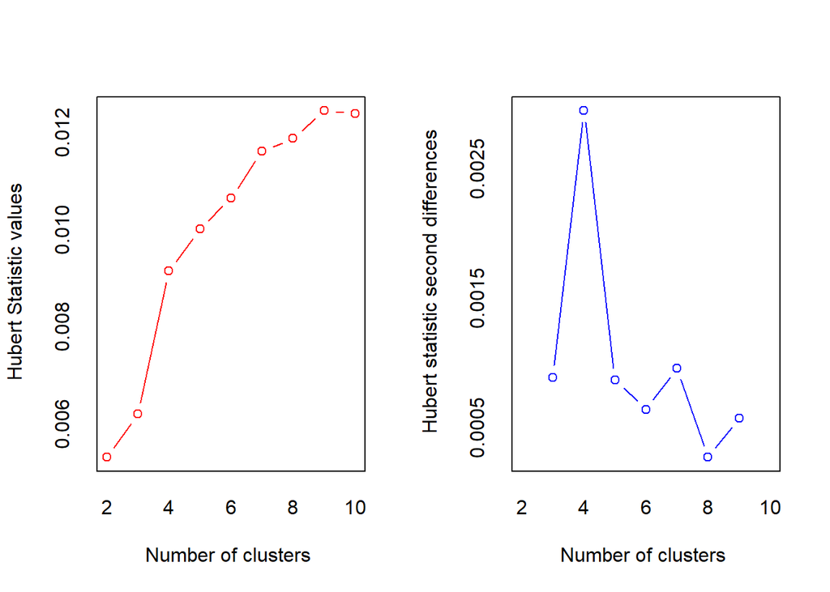

```
## *** : The Hubert index is a graphical method of determining the number of clusters.
##                 In the plot of Hubert index, we seek a significant knee that corresponds to a
##                 significant increase of the value of the measure i.e the significant peak in Hubert
##                 index second differences plot.
##
```

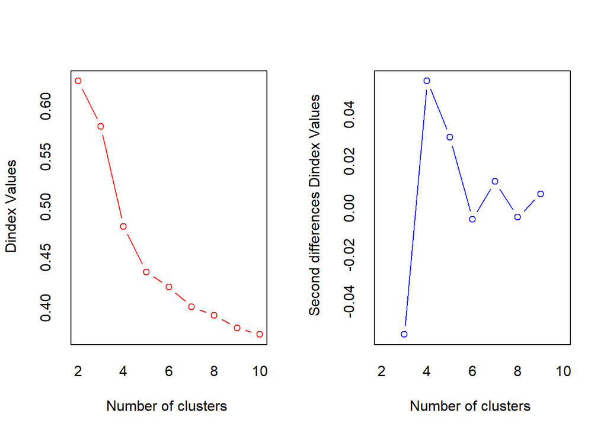

```
## *** : The D index is a graphical method of determining the number of clusters.
##                 In the plot of D index, we seek a significant knee (the significant peak in Dindex
##                 second differences plot) that corresponds to a significant increase of the value of
##                 the measure.
##
## * Among all indices:
## * 4 proposed 2 as the best number of clusters
## * 2 proposed 3 as the best number of clusters
## * 9 proposed 4 as the best number of clusters
## * 3 proposed 5 as the best number of clusters
## * 1 proposed 6 as the best number of clusters
## * 2 proposed 7 as the best number of clusters
## * 2 proposed 10 as the best number of clusters
##
##                    ***** Conclusion *****
##
## * According to the majority rule, the best number of clusters is  4
##
##
```

## Biểu đồ thể hiện k

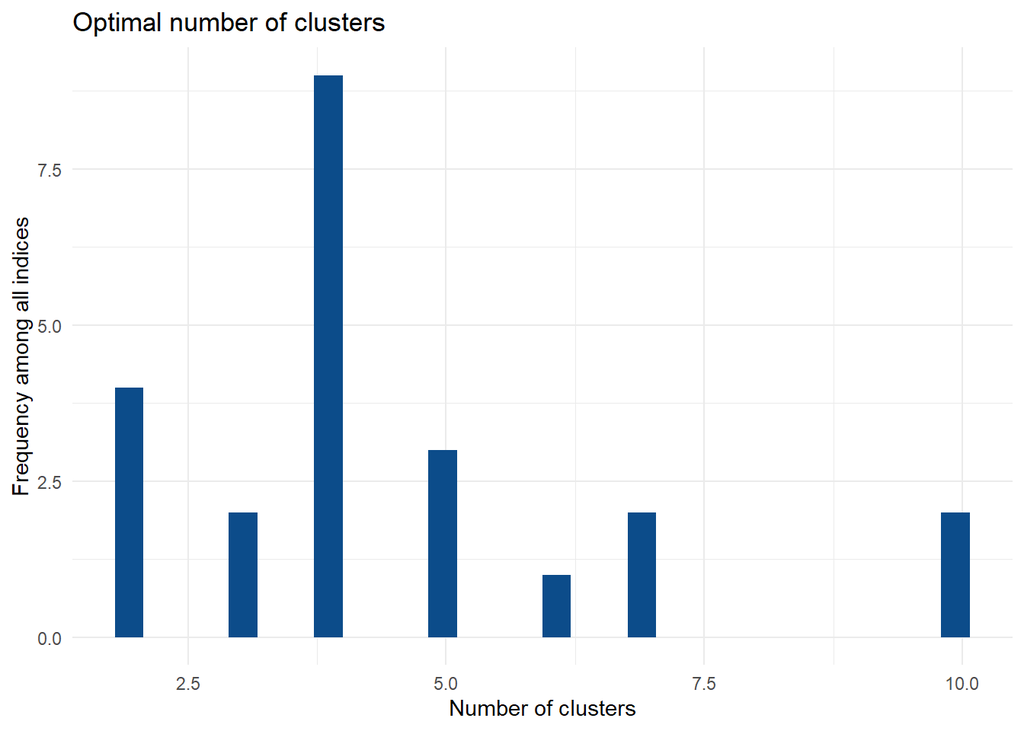

## Kết quả phân tích k-mean với k =4

```
## K-means clustering with 4 clusters of sizes 326, 74, 59, 141
##
## Cluster means:
##   Pur.Vol.No.Promo Pur.Vol.Promo.6 Pur.Vol.Other.Promo   Pr.Cat.1  Pr.Cat.2
## 1        0.9184049      0.05325153          0.02947853 0.16693252 0.7362270
## 2        0.9377027      0.01513514          0.04810811 0.05608108 0.1264865
## 3        0.8757627      0.09322034          0.03186441 0.15084746 0.1755932
## 4        0.9048936      0.05914894          0.03687943 0.70992908 0.2579433
##     Pr.Cat.3   Pr.Cat.4 PropCat.5  PropCat.6   PropCat.8   PropCat.12
## 1 0.05665644 0.04162577 0.5479755 0.09150307 0.080030675 0.0053374233
## 2 0.79378378 0.02527027 0.1021622 0.05729730 0.007972973 0.0018918919
## 3 0.07457627 0.59881356 0.7303390 0.03457627 0.071864407 0.0008474576
## 4 0.01460993 0.01794326 0.3214894 0.13780142 0.122836879 0.0130496454
##    PropCat.15   maxBrCd
## 1 0.031717791 0.3919663
## 2 0.004189189 0.7621216
## 3 0.008813559 0.1277458
## 4 0.029361702 0.2200213
##
## Clustering vector:
##   [1] 1 1 2 2 3 1 1 2 1 4 3 1 3 1 1 1 1 1 3 4 2 2 2 2 2 4 1 1 3 2 2 3 2 2 2 3 3
##  [38] 3 2 2 1 2 2 2 3 1 3 1 2 4 2 1 2 1 2 1 2 3 2 1 1 2 2 1 4 2 1 4 3 1 1 3 2 1
##  [75] 3 4 1 2 1 3 1 2 2 4 1 1 3 1 4 2 4 1 2 4 1 1 2 1 2 1 1 1 3 1 3 1 4 1 1 3 2
## [112] 1 1 3 3 4 1 2 1 1 3 4 1 4 1 2 1 1 1 4 3 1 4 1 2 4 1 1 1 3 3 2 1 2 4 2 2 3
## [149] 1 1 1 1 2 2 1 4 4 2 1 2 2 2 1 1 1 1 1 1 1 1 3 1 1 2 1 1 1 2 2 1 1 1 1 1 1
## [186] 1 3 3 1 4 3 4 1 1 1 1 1 1 4 1 1 3 1 3 2 1 3 1 1 1 1 3 1 1 1 4 1 4 2 4 3 1
## [223] 2 4 1 1 1 1 4 1 2 1 2 1 2 2 2 2 2 4 1 1 3 1 2 1 2 4 4 3 1 4 1 1 1 1 1 2 1
## [260] 1 4 1 1 1 1 1 1 1 1 4 1 1 1 1 1 1 1 1 1 1 1 3 3 1 1 3 1 1 1 4 1 4 1 3 3 1
## [297] 2 1 1 4 1 1 3 1 4 1 1 1 1 4 4 1 1 4 1 1 1 3 1 4 3 4 1 1 1 2 1 2 1 1 1 1 1
## [334] 1 1 3 4 1 1 1 1 1 3 4 1 1 4 4 1 1 1 4 4 1 4 1 4 1 4 3 4 1 3 4 4 4 3 1 4 3
## [371] 1 4 1 1 2 4 1 4 1 1 4 4 1 4 1 4 1 1 1 1 4 4 4 4 1 4 4 1 4 1 4 4 1 1 1 4 4
## [408] 1 1 1 1 4 4 1 4 4 1 4 1 1 1 1 4 1 1 1 1 4 4 1 1 3 1 4 4 1 4 1 1 4 1 1 1 4
## [445] 4 1 1 1 1 3 4 1 1 1 1 1 4 4 4 4 1 3 1 4 4 2 1 1 1 4 4 4 4 1 1 1 1 4 4 4 4
## [482] 4 1 4 4 1 4 1 4 4 1 1 4 1 4 4 4 4 1 1 2 4 1 1 4 4 1 1 3 1 4 3 1 4 1 1 4 1
## [519] 4 1 1 1 1 3 1 1 1 1 1 1 1 2 1 1 1 1 2 1 1 1 1 4 1 4 1 1 1 1 1 4 1 1 4 1 1
## [556] 1 1 1 4 4 4 1 4 1 1 3 1 4 1 4 1 1 4 4 1 2 4 4 4 1 1 4 1 1 1 1 1 1 1 1 1 4
## [593] 1 1 1 1 4 1 1 1
##
## Within cluster sum of squares by cluster:
## [1] 96.77257 10.26820 11.27856 43.16905
##  (between_SS / total_SS =  51.3 %)
##
## Available components:
##
## [1] "cluster"      "centers"      "totss"        "withinss"     "tot.withinss"
## [6] "betweenss"    "size"         "iter"         "ifault"
```

=> Chất lượng của phân vùng dựa trên chỉ số trên là 51,3%

## Biểu đồ phân cụm của k-means

```
## .
##   1   2   3   4
## 326  74  59 141
```

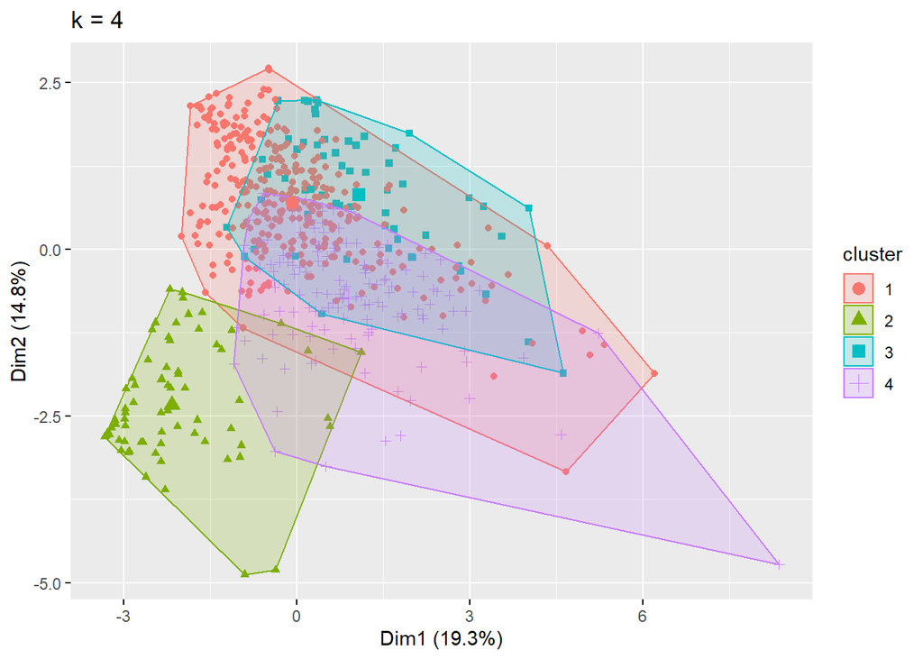

## Chọn k tối ưu - thuật toán K-Medoids

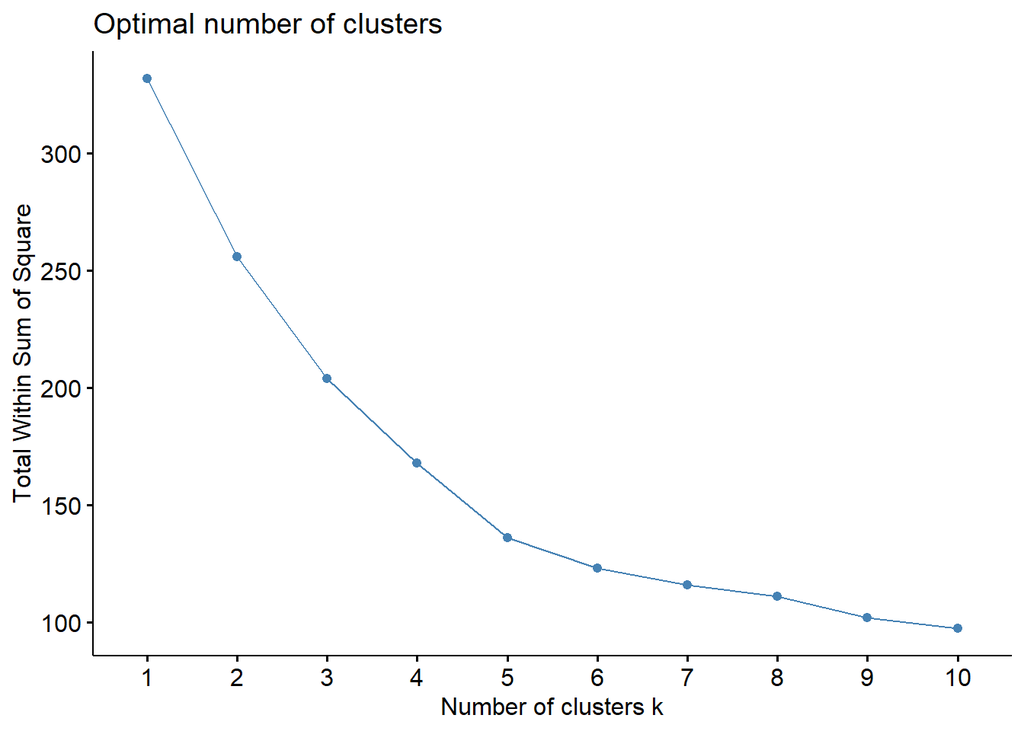

## Kết quả phân tích k-Mediods với k =4

```
## Medoids:
##       ID Pur.Vol.No.Promo Pur.Vol.Promo.6 Pur.Vol.Other.Promo Pr.Cat.1 Pr.Cat.2
## [1,] 443             0.92            0.05                0.02     0.20     0.60
## [2,]  62             0.97            0.00                0.03     0.09     0.11
## [3,] 288             1.00            0.00                0.00     0.14     0.82
## [4,] 199             0.88            0.07                0.06     0.83     0.17
##      Pr.Cat.3 Pr.Cat.4 PropCat.5 PropCat.6 PropCat.8 PropCat.12 PropCat.15
## [1,]     0.14     0.06      0.44      0.10      0.08       0.02          0
## [2,]     0.80     0.01      0.07      0.09      0.01       0.02          0
## [3,]     0.04     0.00      0.86      0.06      0.00       0.00          0
## [4,]     0.00     0.00      0.37      0.09      0.00       0.00          0
##      maxBrCd
## [1,]   0.215
## [2,]   0.797
## [3,]   0.604
```

[output cut: 26 more lines]

## Biểu đồ với k =4

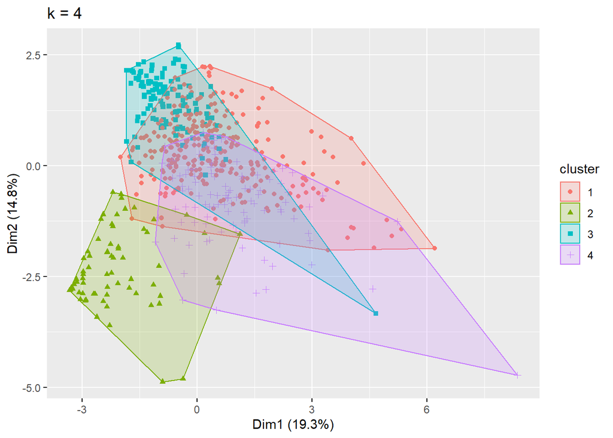

## So sánh 2 thuật toán

```
##   cluster size ave.sil.width
## 1       1  326          0.26
## 2       2   74          0.60
## 3       3   59          0.41
## 4       4  141          0.27
```

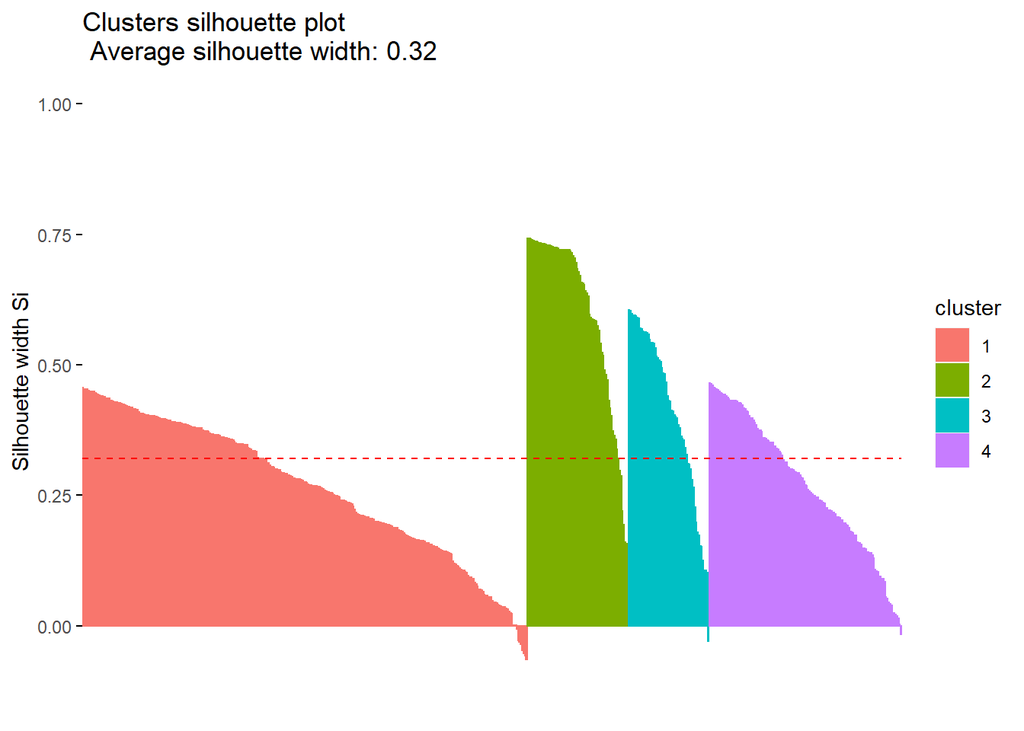

```
##   cluster size ave.sil.width
## 1       1  293          0.07
## 2       2   73          0.61
## 3       3  124          0.42
## 4       4  110          0.27
```

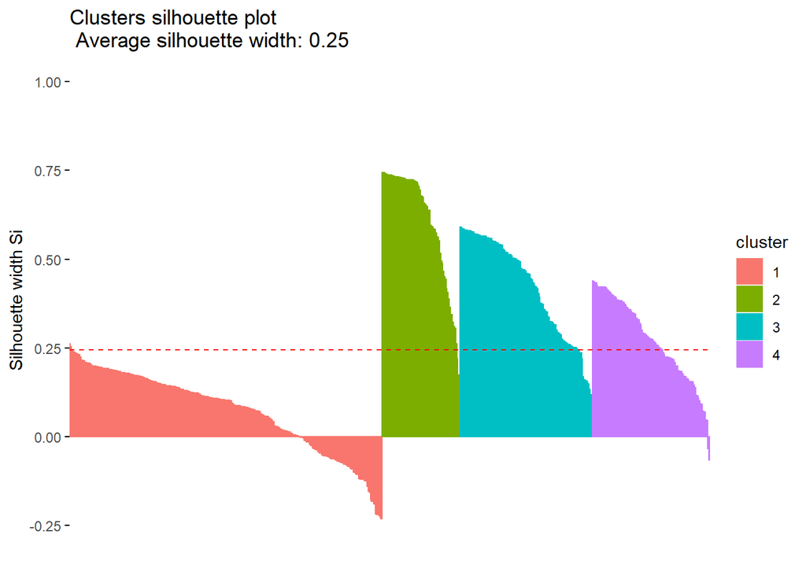

- Dựa vào thông số trên ta thấy phân cụm của Kmeans có thông số Silhouette Coeﬃcient gần 1 hơn so với phân cum bằng K-Medoids nên thuật toán K-Means là thuật toán tốt hơn cho tập dữ liệu này
- Silhouette coeﬀicient là trung bình của các Si. Giá trị càng gần +1 mô tả clustering càng tốt